# SDS230_Final_Project

### Introduction

This project will examine data from Ken French’s website which provides information on the average firm size, monthly return, and beta for 49 different industries, as well as the overall market return and risk free rate. The questions of the project are two-fold: First, we wish to assess whether the returns of different industries behave similarly (do they have similar mean returns, are they correlated, do they have similar book equity to market equity ratios, etc). Second, we wish to assess whether the Capital Asset Pricing Model accurately predicts the cross sectional returns of the various industries.

CAPM is a model that predicts a portfolio’s returns given the portfolio’s market risk. We will test the CAPM using the method pioneered in Fama-Macbeth (1973) by first calculating each industry’s market beta, and then running cross sectional regressions to see whether beta explains the average returns on each industy.

### Data

The variables we plan to use and create in this dataset are:

**Year**

**Industry Percent Return** - The percent return on investment for a given industry in a given year.

**Industry** - the 49 individual industries.

**Composite Industry** - larger industry category that aggregates the 49 individual industries (e.g. TMT, Healthcare…).

**Average Firm Size** - The average market capitalization value of a firm in a given year represented in millions of dollars.

**Book Equity / Market Equity** - a measure of a company’s asset value on the books relative to market valuation.

**Market Return** - Defined as “The return on the overall theoretical market portfolio which includes all assets and having the portfolio weighted for value.”

**Risk Free Rate** - Defined as “the rate of return a hypothetical investment with no risk of financial loss”.

**Beta** - Defined as “a measure of a stock’s volatility in relation to the market” The formula for Beta is:

$\beta_i = \frac{Cov(R_e, R_m)}{Var(R_m)}$

where $R_e$ = the return on an individual portfolio and $R_m$ = the market return.

**Composite Returns** - The percent return on investment for a given composite industry (larger industry catagory) in a given year.

**Composite BE/ME Ratio** - a measure of a company’s asset value on the books relative to market valuation by composite industry.

**Composite Beta** - the composite industry average of “volatility in relation to the market.”

**Composite Size** - the average market capitalization of firms within a composite industry over a year.

The data sets we collected were formatted in such a way that required extensive data cleaning before beginning our analysis. Below are the steps we took:

**First**, we needed to resolve cases of incomplete data across all of our data sets.

**Third**, the data provided in the four different data sets, “BE” (Book to Equity), “size” (Market Value), “returns” (returns in percent for the given period), “rf” (market return for that period), was organized horizontally, with years as rows, each industry (e.g. Agric, Food, Soda…) as columns, and then returns by year and industry in the middle. We needed to aggregate the various industry columns names into one “industry” column, which required transposing each data set.

**Fifth**, we created a new “beta” variable based on the formula indicated above for each composite industry for each year.

**Sixth**, once we formatted each of the four data sets in similar manners, we merged them into one data frame to be able to run tests and analyses on the data. The code for data cleaning can be found in the R-Markdown file.

### Data Cleaning

```r
BE[BE== -99.99] <- NA
size[size == -99.99] <- NA
returns[returns == -99.99] <- NA
rf[rf == -99.99] <- NA
```

Next, we will reformat the year variable to include only the year as oppossed to year-month while finding the yearly averages for the “BEME” and “size” dataframes, while finding total yearly return for the “returns” dataframe. We then adjust the dataframes so the years line up correctly. We have omitted this code for the sake of space - please refer to the R-Markdown file to see more details.

```r
size$Year <- substr(size$Year, 1, 4) #Strip off all ofthe month values
size <- aggregate(.~Year, data = size, mean,  na.action = na.pass)
returns$Year <- substr(returns$Year, 1, 4)
returns <- aggregate(.~Year, data = returns, total_return, na.action = na.pass)
rf$Year <- substr(rf$Year,1,4)
rf <- aggregate(.~Year, data= rf, total_return,  na.action = na.pass)
rf$mktret <- rf$Mkt.RF+rf$RF #This creates the column for market return - done by adding back the risk free rate to the risk free market return
```

We want the data at each time click to be the data that would have been available to someone at that time. Because size and BE/ME are backwards looking calculations but predictive variables of returns, they contain information from the future that would not have been available to someone trying to make a prediction. Therefore, we lag both of these variables by one year.

Before using our datasets, we need to convert them from wide form to long form. Using the melt function, we alter our dataframe such that it transforms from a 89x50 dataframe to a 4361x3 dataframe. We then adjust the names of the columns, eliminate repeated columns, and repeat for our other dataframes (returns and size). This step and the following couple will have muted code to save space. See the RMD file for the code.

Once we have transformed the dataframes into the appropriate form, we can then merge the datasets together into the final, usable dataframe. Because year and industry are repeated so many times in each of the datasets, to merge, we must create a YearInd variable that represents an industry in a unique year. After merging, we delete the repeated columns and rename the remaining ones.

To expand our realm of analysis, we have decided to create a number of variables: composite industry (categorical) and Beta (continuous). Below is the series of code used to create our new variables. We begin with our composite industry variable which recodes our 49 independent industries into eight overarching industries (Healthcare, Industrials, TMT, Financials, Consumer, Utilities, Commodities, and Other). Please see the R-Markdown file for the details of the recoding.

Next, we create Beta for each industry, which represents the covariance of market returns and a given industry returns divided by the variance in market returns.

```r
df <- merge(df, rf, by = "Year")
df$Year <- as.factor(df$Year)
df$Beta <- NA
for(i in unique(df$Ind)){
  temp <- df[df$Ind == i,]
  a <- (cov(temp$returns,temp$mktret))/(var(temp$mktret))
  df$Beta[df$Ind==i] <- a
}
```

Here, we create all of the composite variables for our dataset such as Composite Industry Returns, Composite Size, and Composite BE/ME ratio. We then merge these into a new dataframe.

```r
indreturnscomp <- aggregate(df$returns ~ df$CompInd + df$Year, df, mean)
colnames(indreturnscomp) <- c("CompInd", "Year", "Composite Returns")
aggcompret <- merge(df, indreturnscomp, all.x=T, by = c("Year", "CompInd"))

#composite industry size
indsizecomp <- aggregate(df$size ~ df$CompInd + df$Year, df, mean)
colnames(indsizecomp) <- c("CompInd", "Year", "Composite Size")
#indsizecomp
aggcompsize <- merge(aggcompret, indsizecomp, all.x=T, by = c("Year", "CompInd"))

#composite BE/ME ratio
indbemecomp <- aggregate(df$BEMERatio ~ df$CompInd + df$Year, df, mean)
colnames(indbemecomp) <- c("CompInd", "Year", "Composite BE/ME Ratio")
aggcompbeme <- merge(aggcompsize, indbemecomp, all.x=T, by = c("Year", "CompInd"))

#composite beta and final dataframe
indbetacomp <- aggregate(df$Beta ~ df$CompInd + df$Year, df, mean)
colnames(indbetacomp) <- c("CompInd", "Year", "Composite Beta")
aggcompfin <- merge(aggcompbeme, indbetacomp, all.x=T, by = c("Year", "CompInd"))

#final dataframe
aggcompfin$Year <- as.numeric(aggcompfin$Year)
```

### Graphics

First, we examine a boxplot between firm size and composite industry to examine if there are noticeable differences in the log size between the composite industries. We would need to use a t-test of some sort to examine whether these differences were statistically significant. We added 1 inside the log because some of the firm sizes are technically zero, which causes an error given that we are taking the natural log.

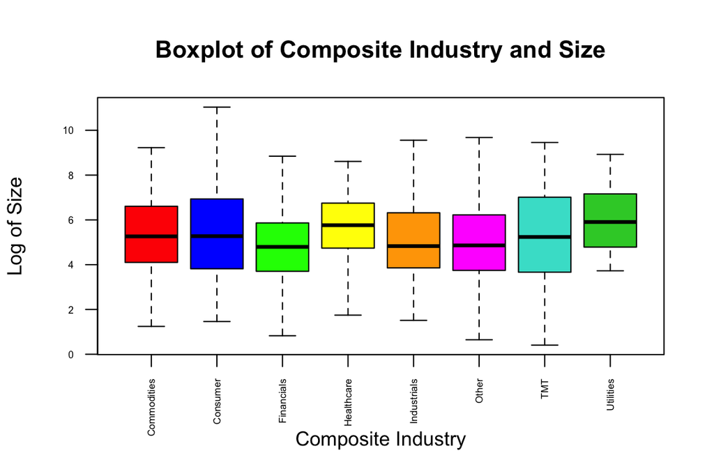

```r
boxplot(log(df$size + 1)~df$CompInd, main = "Boxplot of Composite Industry and Size", col = c("red", "blue", "green", "yellow","orange", "magenta", "turquoise", "lime green"), ylab = "Log of Size", xlab = 'Composite Industry', las = 2, cex.axis = .5)
```

Overall, the industries appear to have relatively similar means and variances and there are no observable skews within any of the industries. This boxplot would lead us to believe that we have a normal distribution within each composite industry (although a normal quantile plot is needed to confirm these findings).

We now examine the returns for each composite industry by year from 1926-2014.

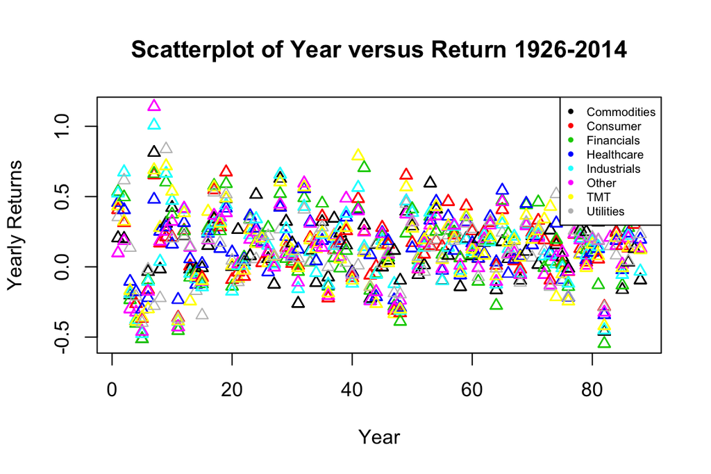

```r
aggcompfin$CompInd <- as.factor(aggcompfin$CompInd)
plot(aggcompfin$`Composite Returns` ~ aggcompfin$Year, main = "Scatterplot of Year versus Return 1926-2014", pch = 24, col = aggcompfin$CompInd, xlab = "Year", ylab = "Yearly Returns")
legend("topright", legend= levels(aggcompfin$CompInd), pch=16, cex = 0.6, col = c(1:9))
```

Overall, there seems to be a lot of variance in the returns throughout the entire period. Given the number of composite industries, however, it is difficult to see any single trend in the graph. As such, we will have to run regression analyses by industry to see any trends for each composite industry.

Now, we will compare specific composite industries to observe how our continuous variables have changed throughout time. We have elected two composite industries at random (TMT and Commodities) in order to limit the number of graphs we are making. We will also limit the number of graphs we print for space purposes - the R-Markdown file includes the code to create these bar graphs.

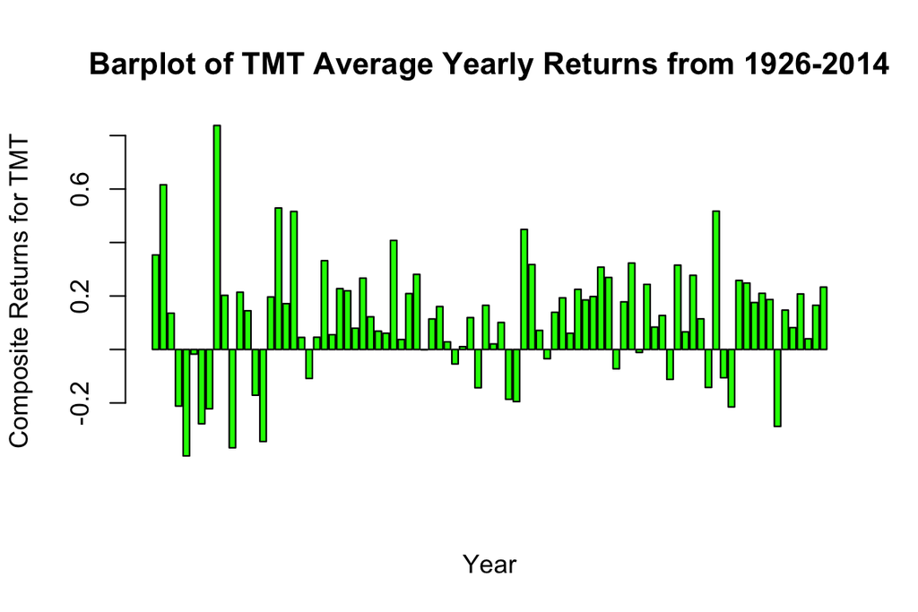

```r
#barplot(single$Composite_BEME_Ratio_TMT, main = "Barplot of TMT BE/ME Ratio from 1926-2014", col = "blue", ylab = "Composite BE/ME for TMT")
barplot(single$Composite_Returns_TMT, main = "Barplot of TMT Average Yearly Returns from 1926-2014", col = "green", ylab = "Composite Returns for TMT", xlab = "Year")
```

```r
#barplot(single$Composite_Size_TMT, main = "Barplot of TMT Composite Size from 1926-2014", col = "green", ylab = "Composite Average Size for TMT")
```

Now, we examine the same graphs for the Commodities industry.

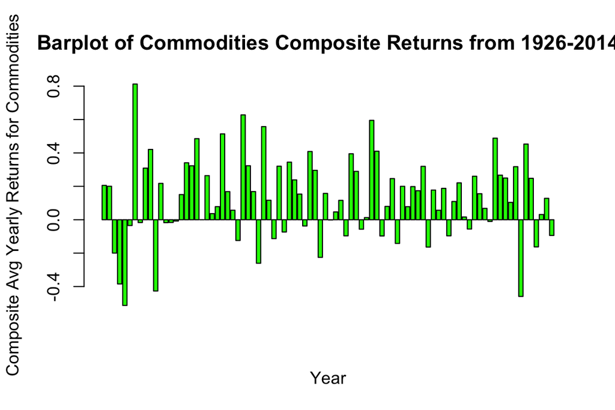

```r
#barplot(single$Composite_BEME_Ratio_Com, main = "Barplot of Commodities BE/ME Ratio from 1926-2014", col = "green", ylab = "Composite BE/ME for Commodities")
barplot(single$Composite_Returns_Com, main = "Barplot of Commodities Composite Returns from 1926-2014", col = "green", ylab = "Composite Avg Yearly Returns for Commodities", xlab = "Year")
```

```r
#barplot(single$Composite_Size_Com, main = "Barplot of Commodities Size from 1926-2014", col = "green", ylab = "Composite Size for Commodities")
```

### Basic Tests

```r
t.test(single$Composite_Returns_TMT, single$Composite_Returns_Com)
```

```
##
##  Welch Two Sample t-test
##
## data:  single$Composite_Returns_TMT and single$Composite_Returns_Com
## t = -0.35297, df = 172.05, p-value = 0.7245
## alternative hypothesis: true difference in means is not equal to 0
## 95 percent confidence interval:
##  -0.08092492  0.05637315
## sample estimates:
## mean of x mean of y
## 0.1140227 0.1262986
```

```r
#only outputting the p-value for the next two t-tests for the sake of space
t2 <- t.test(single$Composite_Size_TMT, single$Composite_Size_Com)$p.value
t2
```

```
## [1] 0.04651164
```

```r
t3 <- t.test(single$Composite_BEME_Ratio_TMT, single$Composite_BEME_Ratio_Com)$p.value
t3
```

```
## [1] 0.02033243
```

Based on the t-test, Composite Returns between TMT and Commodities are not statistically significantly different at any reasonable level of alpha. By contrast, size for the two industries is statistically significant at alpha = 0.05 as the p-value is 0.04651. Based on the boxplot, it appears that TMT is larger than commodities for size. Finally, the BE/ME Ratio between the two industries is statistically significantly different at the 0.05 alpha level as the p-value is 0.02033. Based on the boxplot (which we removed), the BE/ME Ratio for Commodities is larger than TMT. This makes intuitive sense because tech stocks are typically valued at higher multiples of their revenue because more future growth is priced in.

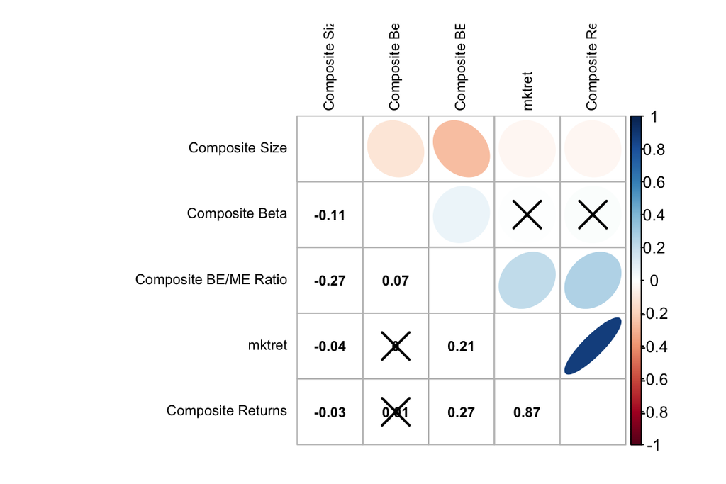

```r
#Now we check for significant correlations at the 95% level and plot them.
sigcorr <- cor.mtest(aggcompfin[,c(9, 11:14)], conf.level = .95)
corrplot.mixed(cor(aggcompfin[,c(9, 11:14)]), lower.col="black", upper = "ellipse", tl.col = "black", number.cex=.7, order = "hclust", tl.pos = "lt", tl.cex=.7, p.mat = sigcorr$p, sig.level = .05, mar=c(1,1,1,1))
```

Overall, the correlations between variables are relatively low. The highest correlation is between market return and composite returns for all of the industries. Composite Beta and Composite BE/ME ratio both have a low negative correlation with composite size, but the correlation is statistically significant at the 95% level. Other than these several correlations, the others are too low to hold much interpretation. We will proceed by analyzing these three correlations through bootstraps and permutation tests.

### Permutation Test

We now conduct a permutation test between composite industry return and composite BE/ME in order to show a non-zero statistically significant correlation between these two variables.

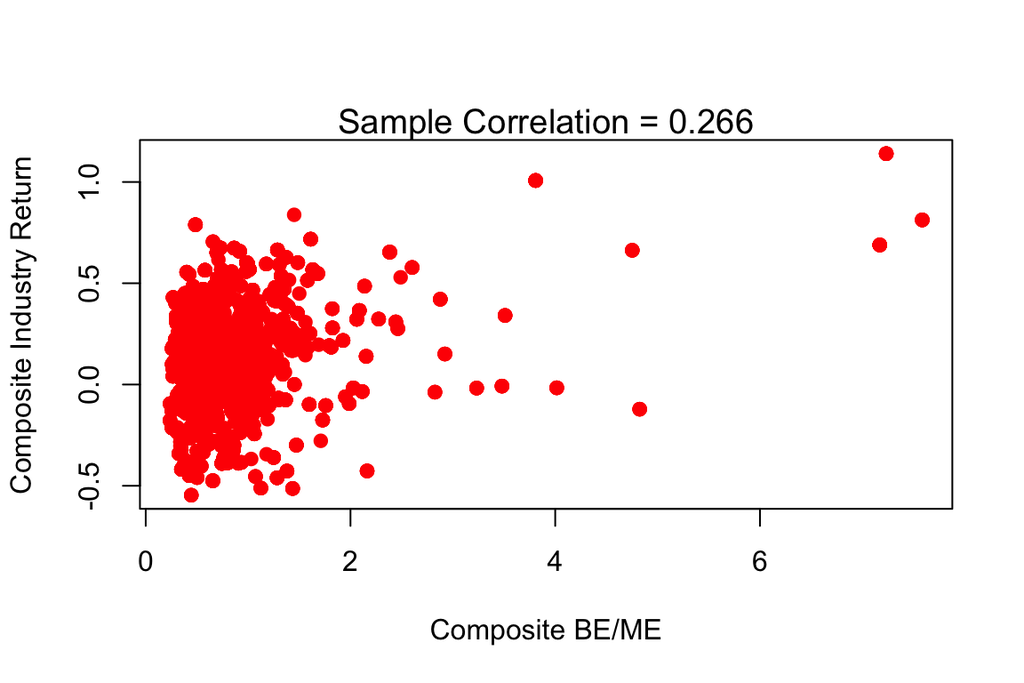

```r
myCor <- function(x,y){
  plot(x,y,pch=19, col="red", xlab = "Composite BE/ME", ylab = "Composite Industry Return")
  mtext(paste("Sample Correlation =", round(cor(x,y),3)), cex=1.2)
}

permCor <- function(x, y, n_samp = 10000, plot = T){
   corResults <- rep(NA, n_samp)
   for (i in 1:n_samp){
      corResults[i] <- cor(x, sample(y))
   }
   pval <- mean(abs(corResults) >= abs(cor(x,y)))
   if (plot == T){
      #Make histogram of permuted correlations
      hist(corResults, col = "yellow", main = "", xlab = "Correlations", breaks = 50,
           xlim = range(corResults,cor(x,y)))
      mtext("Permuted Sample Correlations", cex = 1.2, line = 1)
      mtext(paste("Permuted P-value =",round(pval,5)), cex = 1, line = 0)
      abline(v = cor(x,y), col="blue", lwd=3)
      text(cor(x,y)*.97, 0,paste("Actual Correlation =", round(cor(x,y),2)),srt = 90, adj = 0)
   }
   if (plot == F){
      return(round(pval,5))
   }
}

myCor(aggcompfin$`Composite BE/ME Ratio`, aggcompfin$`Composite Returns`)
```

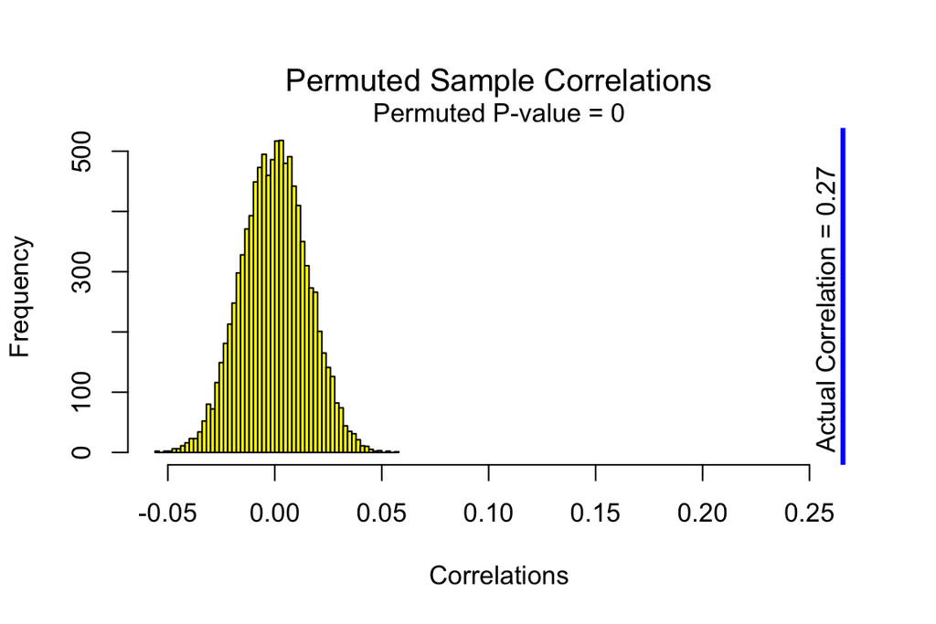

```r
permCor(aggcompfin$`Composite BE/ME Ratio`, aggcompfin$`Composite Returns`, n_samp = 10000, plot = T)
```

The sample correlation returned 0.266, which leads us to believe that there is an extremely weak, positive, linear correlation between composite industry return and composite BE/ME. The permutation test on the other hand, returned a permuted p-value of 0, which allows us to conclude that the actual correlation between composite industry return and composite BE/ME appears to be significant at any reasonable level of alpha.

### Regression Testing CAPM and Bootstrap

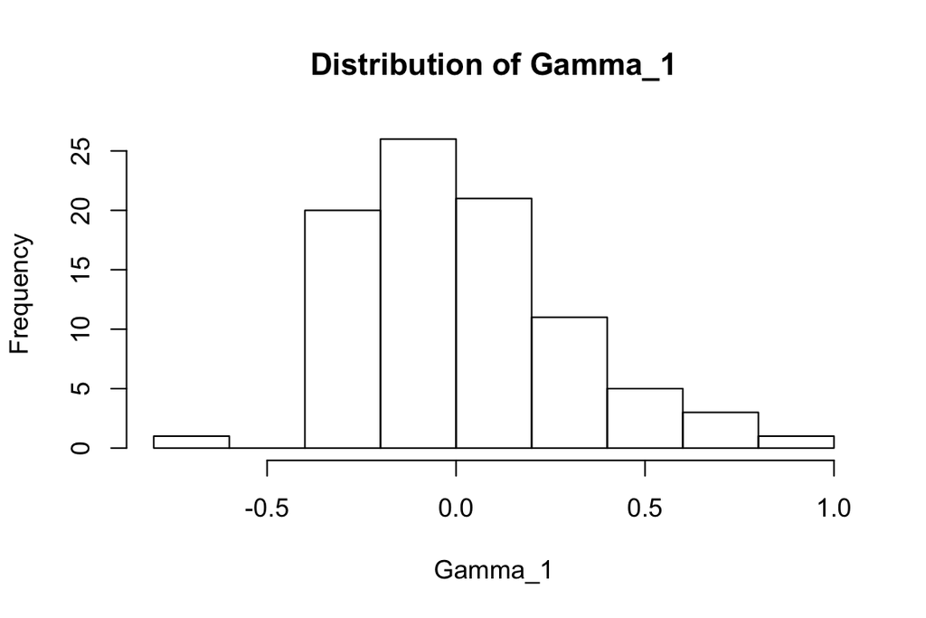

```r
intercepts <- c()
coefficients <- c()
for (i in 1:length(unique(df$Year))){
  year <- unique(df$Year)[i]
  #print(df$returns[df$Year == year])
  temp_df <- na.omit(data.frame(df$returns[df$Year == year], df$Beta[df$Year == year]))
  names(temp_df) <- c('returns', 'beta')
  intercepts <- append(intercepts, as.double(lm(temp_df$returns ~ temp_df$beta)$coefficients[1]))
  coefficients <- append(coefficients, as.double(lm(temp_df$returns ~ temp_df$beta)$coefficients[2]))
}
hist(coefficients, main = 'Distribution of Gamma_1', xlab = 'Gamma_1')
```

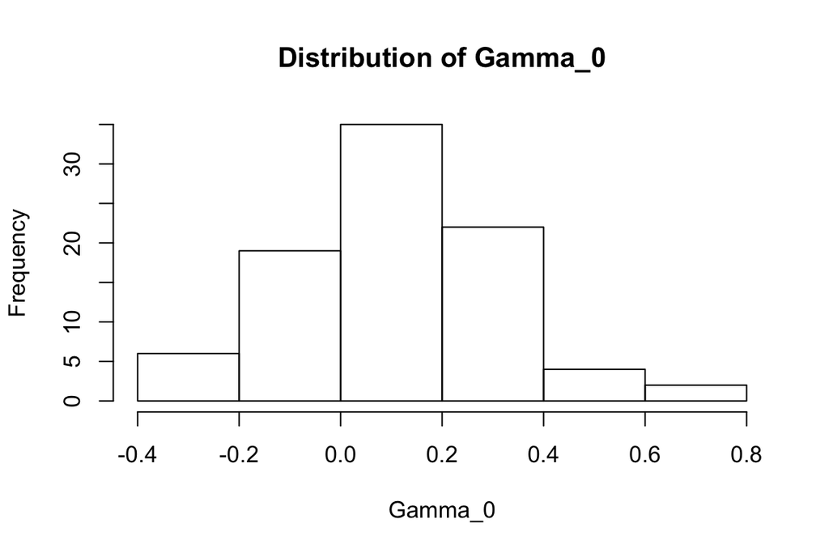

```r
hist(intercepts, main = 'Distribution of Gamma_0', xlab = 'Gamma_0')
```

```r
means <- c(mean(intercepts), mean(coefficients))
sds <- c(sd(intercepts), sd(coefficients))
tstats <- c(mean(intercepts) / (sd(intercepts)/sqrt(length(intercepts))), mean(coefficients) / (sd(coefficients)/sqrt(length(coefficients))))
results_table <- data.frame(c('Gamma_0', 'Gamma_1'), means, sds, tstats)
names(results_table) <- c('Variable', 'Mean', 'SE', 't-stat')

print('The following table contains the resulting means, standard errors, t statistics and P-values for Gamma_0 and Gamma_1')
```

```
## [1] "The following table contains the resulting means, standard errors, t statistics and P-values for Gamma_0 and Gamma_1"
```

```r
results_table
```

```
##   Variable       Mean        SE    t-stat
## 1  Gamma_0 0.10856513 0.2035720 5.0028070
## 2  Gamma_1 0.02577306 0.2777121 0.8705876
```

Just to be sure of our results, we will now create a bootstrapped confidence interval for the true mean of $\gamma _{0}$.

```r
samp_mean <- function(x, i) {
  mean(x[i])
}
results <- boot(intercepts, statistic=samp_mean,
   R=1000)
# get 95% confidence interval
boot.ci(results, type="bca")
```

```
## BOOTSTRAP CONFIDENCE INTERVAL CALCULATIONS
## Based on 1000 bootstrap replicates
##
## CALL :
## boot.ci(boot.out = results, type = "bca")
##
## Intervals :
## Level       BCa
## 95%   ( 0.059,  0.149 )
## Calculations and Intervals on Original Scale
```

We can see here too that 0 is not contained in the bootstrapped confidence interval for $\gamma _{0}$, confirming what we observed in the t test earlier.

Now, we will attempt to find the best model to predict returns, given the data we have. This means we will use the industries, composite industries, BE/ME, and size measures in addition to beta. Some important things to note: measures of size and book equity to market equity will be lagged by 1 time step because that data would not have been available at the time of prediction. We should also note that when calculating beta, we used the entire sample of returns, which we did to get the most accurate measure of each industry’s beta. However, that inevitably includes forward looking data, meaning that in practice the predictive power of beta will likely be lower out of sample. We will be doing a time series regression this time (as opposed to cross sectional), meaning that we won’t do a seperate regression for each year. Instead, our aim will be to predict returns in any time period given the variables. Note: For space purposes, only the final model in the stepwise regression will be printed.

```r
data <- na.omit(df)
#mod1 <- lm(data$returns ~ data$size + data$BEMERatio +  data$Beta + data$CompInd + data$Ind + data$size*data$Beta + data$size*data$BEMERatio + data$BEMERatio*data$Beta + data$CompInd*data$size, data=data)
#ols_step_backward_p(mod1, prem = 0.05)
mod2 <- lm(data$returns ~ data$CompInd + data$BEMERatio*data$Beta, data=data)
summary(mod2)
```

```
##
## Call:
## lm(formula = data$returns ~ data$CompInd + data$BEMERatio * data$Beta,
##     data = data)
##
## Residuals:
##      Min       1Q   Median       3Q      Max
## -1.56132 -0.17768 -0.00031  0.16543  2.26552
##
## Coefficients:
##                           Estimate Std. Error t value Pr(>|t|)
## (Intercept)               0.089109   0.038918   2.290   0.0221 *
## data$CompIndConsumer      0.044871   0.019717   2.276   0.0229 *
## data$CompIndFinancials    0.019047   0.022603   0.843   0.3995
## data$CompIndHealthcare    0.058519   0.023349   2.506   0.0122 *
## data$CompIndIndustrials   0.043752   0.020110   2.176   0.0297 *
## data$CompIndOther         0.008321   0.020321   0.409   0.6822
## data$CompIndTMT           0.049626   0.021773   2.279   0.0227 *
## data$CompIndUtilities     0.007989   0.035895   0.223   0.8239
## data$BEMERatio            0.004399   0.027163   0.162   0.8714
## data$Beta                -0.033615   0.031578  -1.064   0.2872
## data$BEMERatio:data$Beta  0.052648   0.023348   2.255   0.0242 *
## ---
## Signif. codes:  0 '***' 0.001 '**' 0.01 '*' 0.05 '.' 0.1 ' ' 1
##
## Residual standard error: 0.2932 on 3509 degrees of freedom
## Multiple R-squared:  0.03373,    Adjusted R-squared:  0.03097
## F-statistic: 12.25 on 10 and 3509 DF,  p-value: < 2.2e-16
```

Using Backwards Stepwise regression, we eliminate the industry categorical variable, size, and all interaction terms except for the interaction between BEMERatio and Beta (this is why BEME and Beta are included despite them being insignificant on their own. The model automatically includes them because we include the interaction). There are also some composite industries that aren’t significant, but because there are some significant industries within the composite industry categorical variable we have to include them all in the regression.

### ANOVA, Logit, Multinomial, or Webscraping

Earlier, we examined the boxplot of composite industry by size and it appeared that the boxplots were relatively even. We start by examing the sample standard deviations across composite industries to see if we pass our assumptions for ANOVA (ie. the max to min ratio of standard deviations is less than 2).

```r
print("SD by Genre")
```

```
## [1] "SD by Genre"
```

```r
(sds <- tapply(aggcompfin$`Composite Size`, aggcompfin$CompInd, sd))
```

```
## Commodities    Consumer  Financials  Healthcare Industrials       Other
##   1097.8887   3362.6497   1055.5974    755.9716    922.8877   1250.9710
##         TMT   Utilities
##   1253.0774   1718.6425
```

```r
print("Ratio of Max/Min Sample SD")
```

```
## [1] "Ratio of Max/Min Sample SD"
```

```r
round(max(sds)/min(sds),1)
```

```
## [1] 4.4
```

The ratio is 4.4. Thus, our assumption for ANOVA is not satisfied. We will continue with the ANOVA analysis, but we will also use non-parametric tests to see if the variances are the same across composite industries. Specifically, we believe it best to use the Kruskal-Wallace test as it makes no assumptions of normality within each group or that the variances be equal (have a ratio less than 2). We examined our normal quantile plots before, and saw that the data was relatively normally distributed, but not for all genres. Thus, Welch’s ANOVA is not a solid choice in this scenario.

We begin with ANOVA and examine residual plots to see if our assumptions are met:

```r
aov1 <- aov(aggcompfin$`Composite Size` ~ aggcompfin$CompInd)
#We use Tukey comparisons to see differences in the mean size between composite industries
#TukeyHSD(aov1)
#par(mar=c(5,11,4,1))
#plot(TukeyHSD(aov1), las=1)

#We examine our residuals for the ANOVA model
#myResPlots2(aov1, label = "Size Composite Industry")
```

Because size is measured on a dollar scale, we find it best to use a log transformation. We confirm this with the Box-Cox procedure, which has been muted to save space.

```r
#Now, let's see what transformation is suggested
#trans1 <- boxCox(aov1)
#trans1$x[which.max(trans1$y)]
#The suggested transformation is a log. Let's see what happens to our ANOVA model if we use the transformation. The transformation makes sense given that size is on a dollar scale.
transsize <- log(aggcompfin$`Composite Size`)

print("SD by Genre")
```

```
## [1] "SD by Genre"
```

```r
(sds <- tapply(transsize, aggcompfin$CompInd, sd))
```

```
## Commodities    Consumer  Financials  Healthcare Industrials       Other
##    1.403026    2.056953    1.553958    1.010922    1.481583    1.544122
##         TMT   Utilities
##    1.205141    1.396993
```

```r
print("Ratio of Max/Min Sample SD")
```

```
## [1] "Ratio of Max/Min Sample SD"
```

```r
round(max(sds)/min(sds),1)
```

```
## [1] 2
```

```r
#Now the ratio is less than 2 and our assumption for ANOVA is satisfied. We will poroceed with the transformed model
aov2 <- aov(transsize ~ aggcompfin$CompInd)
summary(aov2)
```

```
##                      Df Sum Sq Mean Sq F value Pr(>F)
## aggcompfin$CompInd    7    403   57.54   24.53 <2e-16 ***
## Residuals          4304  10094    2.35
## ---
## Signif. codes:  0 '***' 0.001 '**' 0.01 '*' 0.05 '.' 0.1 ' ' 1
```

*Analysis:* Our second model, using our transformed model in which we took the log of size, shows statistically significant differences between composite industries given that the p-value is lower than any reasonable alpha.

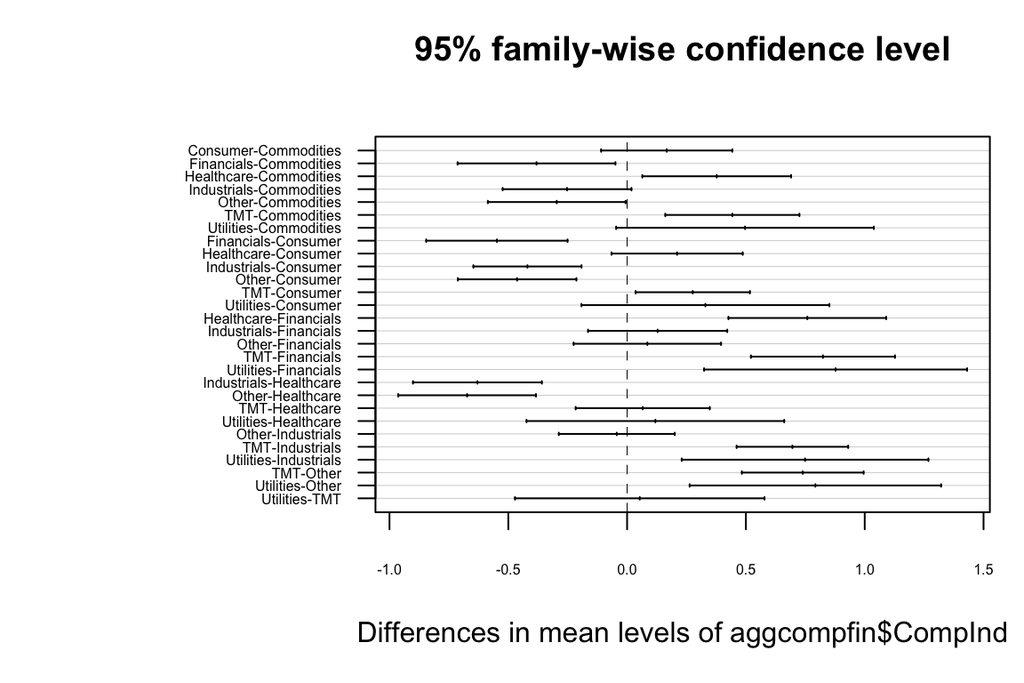

```r
#pairwise.t.test(transsize, aggcompfin$CompInd)
#TukeyHSD(aov2)
par(mar=c(5,11,4,1))
plot(TukeyHSD(aov2), las=1, cex.axis = 0.5)
```

Before we continue with our non-parametric tests, we will use Bartlett’s and Levene’s test to see if variances are the equal. We are not using Bartlett’s test because it assumes a normal distribution for transsize, which we know is not the case.

```r
leveneTest(transsize, aggcompfin$CompInd)
```

```
## Levene's Test for Homogeneity of Variance (center = median)
##         Df F value    Pr(>F)
## group    7    60.6 < 2.2e-16 ***
##       4304
## ---
## Signif. codes:  0 '***' 0.001 '**' 0.01 '*' 0.05 '.' 0.1 ' ' 1
```

```r
#Now, with Kruskal's test
kruskal.test(transsize ~ aggcompfin$CompInd)
```

```
##
##  Kruskal-Wallis rank sum test
##
## data:  transsize by aggcompfin$CompInd
## Kruskal-Wallis chi-squared = 213.83, df = 7, p-value < 2.2e-16
```

```r
#Comparing to One-Way ANOVA
summary.aov(aov(transsize ~ aggcompfin$CompInd))
```

```
##                      Df Sum Sq Mean Sq F value Pr(>F)
## aggcompfin$CompInd    7    403   57.54   24.53 <2e-16 ***
## Residuals          4304  10094    2.35
## ---
## Signif. codes:  0 '***' 0.001 '**' 0.01 '*' 0.05 '.' 0.1 ' ' 1
```

### Final Comments

At the beginning of this project we set out with two main goals: to explore the variability in returns and characteristics of different industries over time, and to test the CAPM. Regarding the first objective, we observed that returns were actually very similar for most industries in the long run. From our tests, we didn’t see much statistically dignificant difference in the mean returns since 1926 of each industry. However, we did notice variablility in some of the other metrics, such as size or BE/ME. For example, we noticed that TMT companies have a statistically significantly lower BE/ME ratio than commodities, meaning that the market gives them a higher valuation relative to their tangible assets. We also noticed that over time, certain companies, especially technology companies, tend to be larger in market value than firms in other sectors.

We also rejected the CAPM by exploring whether market risk was able to explain the yearly cross section of industry returns. We found that there were unexplained sources of return in the model, meaning that either markets do not efficiently compensate investors for the risk they take or there are other sources of risk we did not include in the model (technically one could also argue that our estimates for beta were wrong, but it is hard to imagine that a small amount of estimation error could cause a t stat of 5). Either way, we showed with a high degree of statistical certainty that CAPM doesn’t work.